# Story 1

Mei Qi Ng

2026-09-15

## Approach

The objective of this analysis is to assess the fund allocations from the Infrastructure Investment and Jobs Act (IIJA) from March 2023 in combination with the information from the U.S. Census Population Estimates and 2020 Presidential Election Results. The analysis will address two primary questions

- Is the allocation equitable based on the population of each State and Territory?
- Does the allocation favor the political interests of the Biden administration?

## Data source

- IIJA Funding Data: Provided via bright space assignment file (IIJA FUNDING AS OF MARCH 2023.xlsx)
- U.S. Census Population Estimates: Sourced from the U.S. Census Bureau’s Population Estimates Program (NST-EST2023-ALLDATA) website - https://www.census.gov/programs-surveys/popest/data.html
- 2020 Presidential Election Results: Sourced from MIT Election Data and Science Lab (MEDSL) website - https://dataverse.harvard.edu/dataset.xhtml?persistentId=doi:10.7910/DVN/42MVDX

## Load R package, clean and merge data sets

```r
library(tidyverse)
library(scales)
#source all data
statefund <-read.csv("https://raw.githubusercontent.com/meiqing39/DATA-608/refs/heads/main/IIJA%20FUNDING%20AS%20OF%20MARCH%202023.csv")


census_pop <- read.csv("https://raw.githubusercontent.com/meiqing39/DATA-608/refs/heads/main/2023%20ANNUAL%20STATE%20POPULATION%20ESTIMATE.csv")

election <- read.csv("https://raw.githubusercontent.com/meiqing39/DATA-608/refs/heads/main/1976-2024-president.csv")


#  Data Wrangle
pop <- census_pop |>
  select(State= NAME, Population = POPESTIMATE2020) |>
  filter(!State %in% c("United States", "Northeast Region", "Midwest Region", "South Region", "West Region")) |> mutate(State = toupper(State))


statefund <-statefund |>
 rename(State = 'State..Teritory.or.Tribal.Nation', Total_Billions = 'Total..Billions.')

election_win <- election |>
  filter(year==2020) |>
  group_by(state) |>
  slice_max (order_by = candidatevotes, n = 1) |>
  ungroup() |>
  mutate(State = toupper(state),
  Winner = ifelse(party_simplified == "DEMOCRAT", "Biden",
           ifelse(party_simplified == "REPUBLICAN", "Trump", "Other"))) |>
  select(State,Winner)
```

```r
#Merge all 3 dataset

final<- statefund %>%
  left_join(pop, by = "State") |>
  left_join(election_win, by = "State") |>
  filter(!is.na(Winner)) |>
  mutate(
    Funding_Per_Capita = (Total_Billions * 1e9) / Population)
```

# Visualization

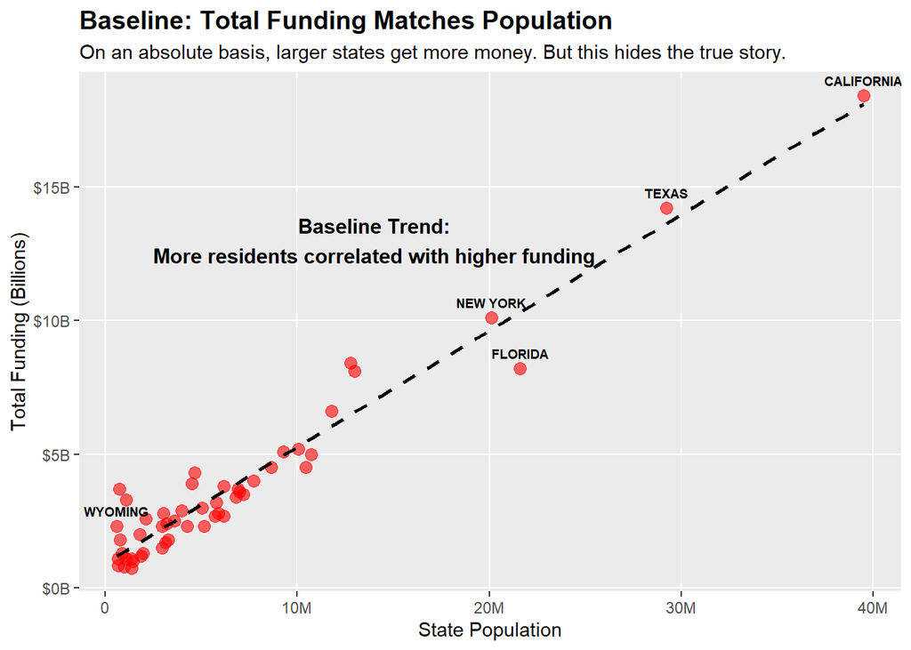

```r
# CHART 1: Total Funding vs Population
ggplot(final, aes(x = Population, y = Total_Billions)) +
  geom_point(alpha = 0.6, size = 3, color = "red") +
  geom_smooth(method = "lm", se = FALSE, color = "black", linetype = "dashed") +
  geom_text(
    data = filter(final, State %in% c("CALIFORNIA", "TEXAS", "NEW YORK", "FLORIDA", "WYOMING")),
    aes(label = State),
    vjust = -1, # Pushes text above  dot
    fontface = "bold",
    size = 2.5
  ) +
  annotate(
    "text", x = 14000000, y = 13,
    label = "Baseline Trend:\nMore residents correlated with higher funding", fontface = "bold", color = "black", size = 4
  ) +
  scale_x_continuous(labels = label_number(scale_cut = cut_short_scale())) +
  scale_y_continuous(labels = dollar_format(suffix = "B")) +
  labs(
    title = "Baseline: Total Funding Matches Population",
    subtitle = "On an absolute basis, larger states get more money. But this hides the true story.",
    x = "State Population",
    y = "Total Funding (Billions)"
  ) +
  theme(
    plot.title = element_text(face = "bold", size = 14),
    panel.grid.minor = element_blank()
  )
```

## Question 1: Is the allocation equitable based on population

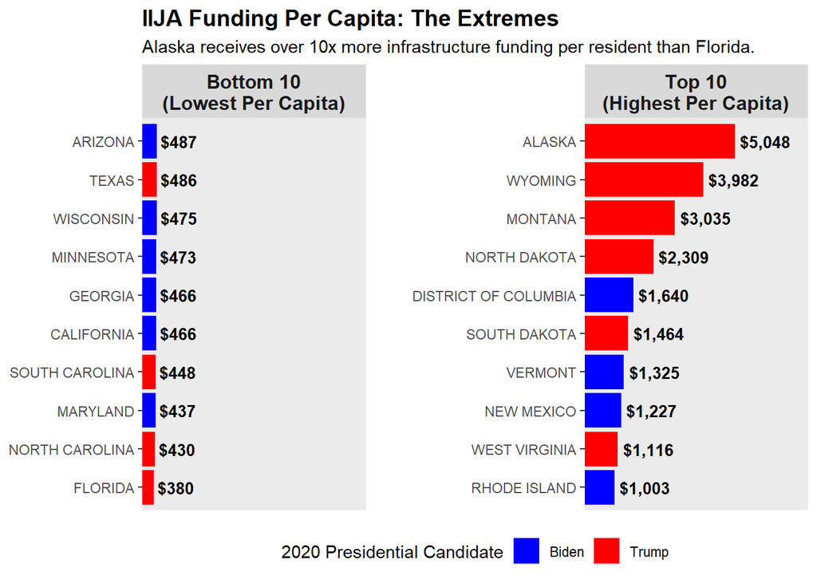

```r
# Create top 10 and bottom 10
top_10 <- final |>
  slice_max(order_by = Funding_Per_Capita, n = 10) |>
  mutate(Group = "Top 10\n(Highest Per Capita)")

bottom_10 <- final |>
  slice_min(order_by = Funding_Per_Capita, n = 10) |>
  mutate(Group = "Bottom 10\n(Lowest Per Capita)")

# Bind together sort by funding amount
q1<- bind_rows(top_10, bottom_10) |>
  mutate(State = reorder(State, Funding_Per_Capita))

# plot
ggplot(q1, aes(x = Funding_Per_Capita, y = State, fill = Winner)) +
  geom_col() +
  geom_text(aes(label = dollar(Funding_Per_Capita, accuracy = 1)),  #add $ values to bars
            hjust = -0.1, size = 3.5, fontface = "bold") +
  facet_wrap(~Group, scales = "free_y") +
  scale_fill_manual(values = c("Biden" = "blue", "Trump" = "red")) +
  scale_x_continuous(expand = expansion(mult = c(0, 0.25))) +
  labs(
    title = "IIJA Funding Per Capita: The Extremes",
    subtitle = "Alaska receives over 10x more infrastructure funding per resident than Florida.",
    x = NULL,
    y = NULL,
    fill = "2020 Presidential Candidate"
  ) +
  theme(
    plot.title = element_text(face = "bold", size = 14),
    strip.text = element_text(face = "bold", size = 12),
    legend.position = "bottom", # move legend to bottom
    panel.spacing = unit(2, "lines"),
    axis.text.x = element_blank(), # REMOVED X AXIS NUMBERS
    axis.ticks.x = element_blank(), # REMOVED X AXIS TICKS
    panel.grid = element_blank() # REMOVED ALL GRID LINES
  ) +
  expand_limits(x = 6000)
```